[figure not shown]

Лабораторнаяработа№2

Имитационноемоделирование

Петрова Алевтина Александровна 2026-03-

02

Цель работы

Цель данной работы — изучить основные модели SIR и Лотки–Вольтерры, а так же изучить

аспекты их программной реализации.

Подготовка рабочего пространства

В этом разделе мы будем использовать уже известные нам скрипты из 1ой лабораторной

работы.

Создадим каталог проекта DrWatson с помощью скрипта setup_project.jl (рис. 1).

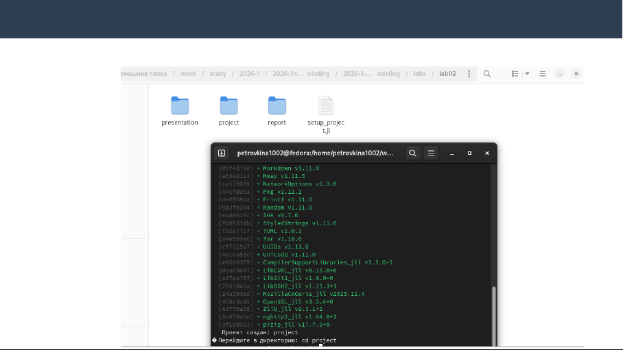

Подготовка рабочего пространства

[figure not shown]

Подготовка рабочего пространства

Добавим необходимые пакеты с помощью скрипта add_packages.jl (рис. 2).

Подготовка рабочего пространства

Проверим корректность установки с помощью скрипта scripts/test_setup.jl (рис. 3).

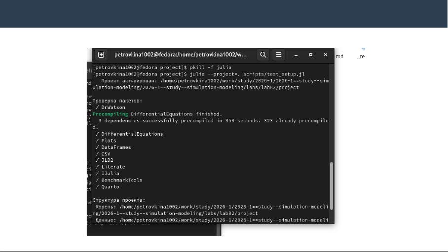

Подготовка рабочего пространства

Подготовка рабочего пространства

Рисунок 3: Проверка установки

[figure not shown]

Модель SIR

Модель SIR

Создаём файл scripts/sir_ode.jl с реализацией модели (рис. 4).

[figure not shown]

Модель SIR

Создадим производные форматы (рис. 5).

[figure not shown]

Модель SIR

Просмотрим каталог с графиками (рис. 6).

[figure not shown]

Модель SIR

Просмотрим qmd файл (рис. 7).

[figure not shown]

Модель SIR

[figure not shown]

Модель Лотки–Вольтерры

Модель Лотки–Вольтерры

Модель Лотки–Вольтерры

Создадим производные форматы (рис. 10).

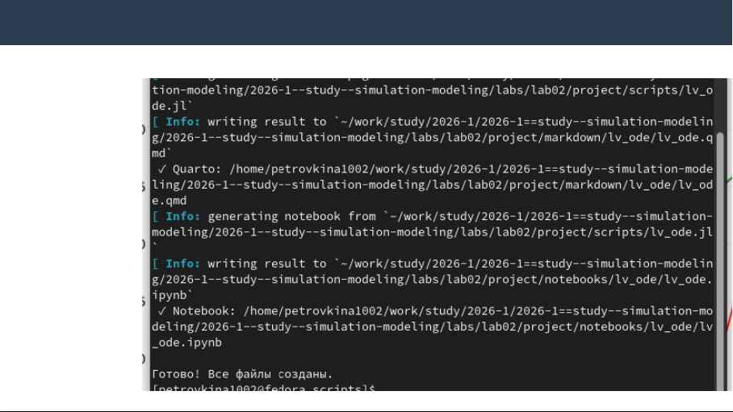

Модель Лотки–Вольтерры

Модель Лотки–Вольтерры

Просмотрим каталог с графиками (рис. 11).

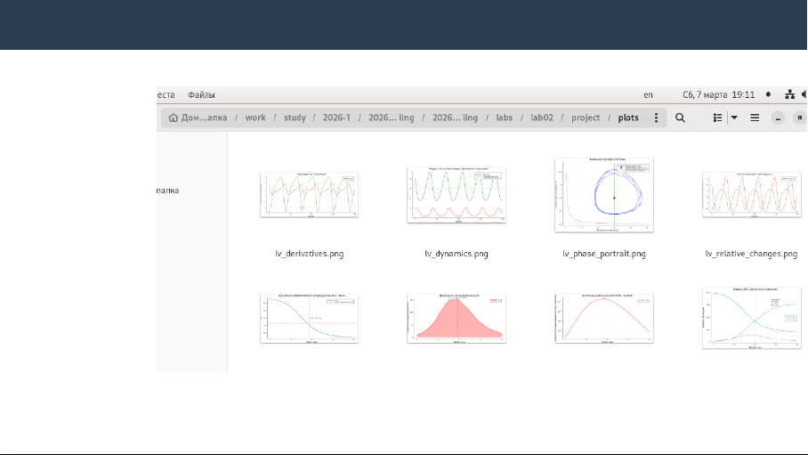

Модель Лотки–Вольтерры

Рисунок 11: Каталог с графиками

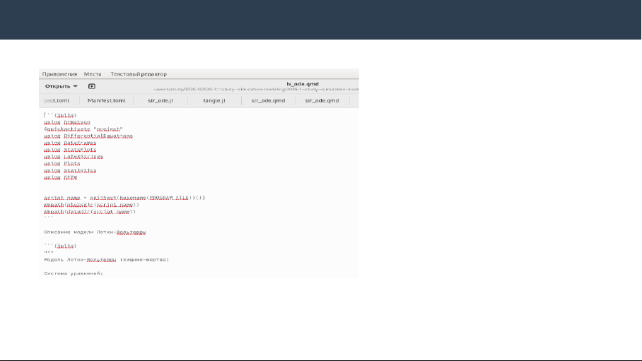

Модель Лотки–Вольтерры

Просмотрим qmd файл (рис. 12).

[figure not shown]

Модель Лотки–Вольтерры

Выводы

В ходе данной лабораторной работы мной были изучены основные модели SIR и

Лотки–Вольтерры, а так же аспекты их программной реализации.